# Multivariate responses

Peter Ralph

Advanced Biological Statistics

# When you’ve got more than one response variable

How often do you really just measure *one* thing?

Even if you’re interested in just one thing, how often is there *one* way to measure it?

## Examples

- how oral and axillary temperature depend on age and treatment
- how gene expression in four tissue types varies with time of day, sex, and metabolic state
- how jaw length and eye size vary with age and habitat

## Things we might want to know

- How do the responses depend on the predictors?
- How do the responses *covary* after accounting for the predictors?

$\ast$ “predictor” = “explanatory variable”

# Multivariate model

Suppose the *responses*, $(X_1, \ldots, X_k)$ depend on the *predictors* $(Y_1, \ldots, Y_m)$.

$$\begin{aligned}
\text{(response)}_1 &= \text{(intercept)}_1 + \text{(predictors)}_1 + \text{(noise)}_1 \\
\vdots & \qquad \vdots \\
\text{(response)}_k &= \text{(intercept)}_k + \text{(predictors)}_k + \text{(noise)}_k
\end{aligned}$$

In symbols,
$$\begin{aligned}
X_1 &= \beta_{0,1} + \beta_{1,1} Y_1 + \cdots + \beta_{m,1} Y_m + \epsilon_1 \\
\vdots & \qquad \vdots \\
X_k &= \beta_{0,k} + \beta_{1,k} Y_1 + \cdots + \beta_{m,k} Y_m + \epsilon_k
\end{aligned}$$

and the *noise* is
$$\begin{aligned}
\epsilon &\sim \MVN(0, \Sigma) .
\end{aligned}$$

(interlude on [the multivariate normal distribution](https://en.wikipedia.org/wiki/Multivariate_normal_distribution))

# Baby birds

## https://doi.org/10.1086/662172

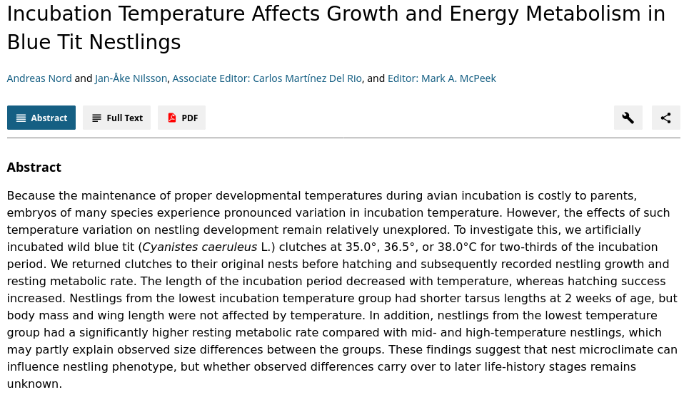

Incubation Temperature Affects Growth and Energy Metabolism in Blue Tit Nestlings. Andreas Nord and Jan-Åke Nilsson The American Naturalist 2011 178:5, 639-651

Their data, at ../Datasets/Incubation_temperature/nestling_biometric_data.txt:

```r
nestlings <- read.table("../Datasets/Incubation_temperature/nestling_biometric_data.txt", header=TRUE, stringsAsFactors=TRUE)
nestlings$treat <- factor(nestlings$treat, levels=c("L", "M", "H"))  # enforce a sensible ordering
```

[output not shown]

[output cut: 1099 more lines]

## Sample sizes:

There are 1113 nestlings from 127 distinct nests; of these, 291 were incubated at the `L` temperature, 434 at the `M` temperature, and 388 at the `H` temperature.

```r
with(nestlings, table(nest, treat))
```

```
##       treat
## nest    L  M  H
##   11    0 11  0
##   112   0  0 11
##   119   0  6  0
##   158   9  0  0
##   159   5  0  0
##   161   0  0  6
##   17    0  0  9
##   176   0  0  8
##   185   0  0 10
##   189   0  0  8
##   191   0  0  7
##   203   0 10  0
##   204   0  0  7
```

[output cut: 114 more lines]

## Response variables

We’ll look at mass and tarsus length on days 6 and 14. Color = treatment:

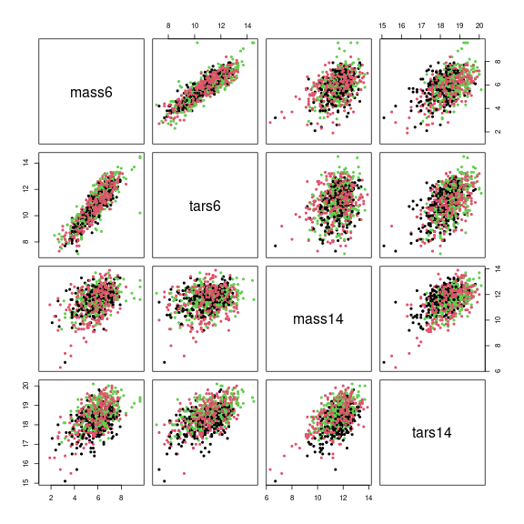

## Questions

1. How much are the four measures of size affected by incubation temperature?
2. How does this effect (if any) compare to other sources of variation?
3. Is there an effect of “nest”, and is it correlated between the four measures?
4. How correlated are the four measurements, after accounting for other variables?

# A multivariate model

We’d like to fit
$$\begin{aligned}
\text{mass6}[i] &= \beta_{1,\text{treat[i]}} + \epsilon_{1,i} \\
\text{tarsus6}[i] &= \beta_{2,\text{treat[i]}} + \epsilon_{2,i} \\
\text{mass14}[i] &= \beta_{3,\text{treat[i]}} + \epsilon_{3,i} \\
\text{tarsus14}[i] &= \beta_{4,\text{treat[i]}} + \epsilon_{4,i} \\
\epsilon_i &\sim \MVN(0, \Sigma) .
\end{aligned}$$

- $\beta$ is the mean effect of each *treatment*
- $\epsilon$ are the *residuals*
- $\Sigma$ is the covariance matrix of the residuals

```r
bf1 <- brmsformula( mvbind(mass6, tars6, mass14, tars14) ~ treat )
priors <- set_prior("normal(0, 5)", class='b', resp=c("mass6", "tars6", "mass14", "tars14"))
bm1 <- brm( bf1 + set_rescor(TRUE), data=nestlings,
            prior=priors)
```

**Notes:**

1. `set_rescor(TRUE)` enables *residual correlations*.
2. With `set_rescor(FALSE)` we’d just have *four independent linear models*.
3. This:

```
brmsformula(
    mvbind(mass6, tars6, mass14, tars14) ~ treat
)
```

is just shorthand for this:

```
( brmsformula( mass6 ~ treat ) +
   brmsformula( tars6 ~ treat ) +
   brmsformula( mass14 ~ treat ) +
   brmsformula( tars14 ~ treat ) )
```

## Summary:

```r
summary(bm1)
```

```
##  Family: MV(gaussian, gaussian, gaussian, gaussian)
##   Links: mu = identity; sigma = identity
##          mu = identity; sigma = identity
##          mu = identity; sigma = identity
##          mu = identity; sigma = identity
## Formula: mass6 ~ treat
##          tars6 ~ treat
##          mass14 ~ treat
##          tars14 ~ treat
##    Data: nestlings (Number of observations: 862)
##   Draws: 4 chains, each with iter = 2000; warmup = 1000; thin = 1;
##          total post-warmup draws = 4000
##
## Population-Level Effects:
##                  Estimate Est.Error l-95% CI u-95% CI Rhat Bulk_ESS Tail_ESS
## mass6_Intercept      5.92      0.06     5.80     6.05 1.00     2094     2326
## tars6_Intercept     10.86      0.08    10.71    11.02 1.00     2250     2468
## mass14_Intercept    11.61      0.06    11.49    11.73 1.00     2604     2555
## tars14_Intercept    18.15      0.04    18.07    18.24 1.00     2488     2691
## mass6_treatM        -0.04      0.08    -0.21     0.12 1.00     2291     2635
## mass6_treatH         0.17      0.09     0.00     0.34 1.00     2283     2715
## tars6_treatM         0.13      0.10    -0.07     0.34 1.00     2330     2779
## tars6_treatH         0.35      0.11     0.14     0.55 1.00     2297     2410
## mass14_treatM       -0.18      0.08    -0.33    -0.03 1.00     2931     3466
## mass14_treatH        0.00      0.08    -0.15     0.16 1.00     3001     3294
## tars14_treatM        0.28      0.05     0.17     0.39 1.00     2639     3016
## tars14_treatH        0.44      0.06     0.33     0.55 1.00     2689     2651
##
## Family Specific Parameters:
##              Estimate Est.Error l-95% CI u-95% CI Rhat Bulk_ESS Tail_ESS
## sigma_mass6      1.00      0.02     0.95     1.05 1.00     2980     3144
## sigma_tars6      1.22      0.03     1.17     1.28 1.00     2724     2875
## sigma_mass14     0.91      0.02     0.87     0.95 1.00     4230     3137
## sigma_tars14     0.63      0.02     0.61     0.67 1.00     3931     2984
##
## Residual Correlations:
##                       Estimate Est.Error l-95% CI u-95% CI Rhat Bulk_ESS Tail_ESS
## rescor(mass6,tars6)       0.85      0.01     0.84     0.87 1.00     3162     2862
## rescor(mass6,mass14)      0.43      0.03     0.38     0.48 1.00     3567     2825
## rescor(tars6,mass14)      0.27      0.03     0.21     0.34 1.00     3374     2673
## rescor(mass6,tars14)      0.45      0.03     0.40     0.51 1.00     3370     3316
## rescor(tars6,tars14)      0.53      0.02     0.48     0.57 1.00     3392     2821
## rescor(mass14,tars14)     0.54      0.02     0.49     0.59 1.00     4270     2958
##
## Draws were sampled using sampling(NUTS). For each parameter, Bulk_ESS
## and Tail_ESS are effective sample size measures, and Rhat is the potential
## scale reduction factor on split chains (at convergence, Rhat = 1).
```

Let’s compare the residual correlations with the actual correlations in the data:

```r
cor(nestlings[,4:7], use='pairwise')
```

```
##         mass6  tars6 mass14 tars14
## mass6  1.0000 0.8684 0.4433 0.4894
## tars6  0.8684 1.0000 0.2776 0.5347
## mass14 0.4433 0.2776 1.0000 0.5409
## tars14 0.4894 0.5347 0.5409 1.0000
```

## Conditional effects:

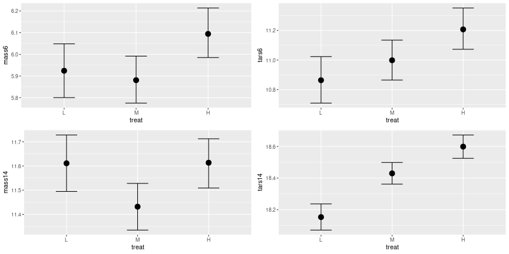

# But what about the “nest” effect?

We assumed that the residuals are independent between nestlings.

But, some are from the same nest?

Seems bad.

Also, recall that

3. Is there an effect of “nest”, and is it correlated between the four measures?

## Exercise:

Without fitting a model, how would you estimate the “nest effect” on tarsus length and mass at 6 days?

Let’s add *random effects* by nest:
$$\begin{aligned}
\text{mass6}[i] &= \beta_{1,\text{treat[i]}} + \gamma_{1,\text{nest[i]}} + \epsilon_{1,i} \\
\text{tarsus6}[i] &= \beta_{2,\text{treat[i]}} + \gamma_{2,\text{nest[i]}} + \epsilon_{2,i} \\
\text{mass14}[i] &= \beta_{3,\text{treat[i]}} + \gamma_{3,\text{nest[i]}} + \epsilon_{3,i} \\
\text{tarsus14}[i] &= \beta_{4,\text{treat[i]}} + \gamma_{4,\text{nest[i]}} + \epsilon_{4,i} \\
\epsilon_i &\sim \MVN(0, \Sigma) \\
\gamma_n &\sim \MVN(0, S)
\end{aligned}$$

Here:

- $\beta$ is the mean effect of each *treatment*
- $\epsilon$ are the *residuals*
- $\Sigma$ is the covariance matrix of the residuals
- $S$ is the **covariance matrix of nest effects**

```r
bf2 <- brmsformula( mvbind(mass6, tars6, mass14, tars14) ~ treat + (1|n|nest) )
bm2 <- brm( bf2 + set_rescor(TRUE), data=nestlings, prior=priors )
```

**New feature:**

```
mvbind(mass6, tars6, mass14, tars14) ~ treat + (1|n|nest)
```

Here `(1|n|nest)` means that the random effects will be *correlated* with each other (and all others with label `n`).

## Summary:

```r
summary(bm2)
```

```
##  Family: MV(gaussian, gaussian, gaussian, gaussian)
##   Links: mu = identity; sigma = identity
##          mu = identity; sigma = identity
##          mu = identity; sigma = identity
##          mu = identity; sigma = identity
## Formula: mass6 ~ treat + (1 | n | nest)
##          tars6 ~ treat + (1 | n | nest)
##          mass14 ~ treat + (1 | n | nest)
##          tars14 ~ treat + (1 | n | nest)
##    Data: nestlings (Number of observations: 862)
##   Draws: 4 chains, each with iter = 2000; warmup = 1000; thin = 1;
##          total post-warmup draws = 4000
##
## Group-Level Effects:
## ~nest (Number of levels: 103)
##                                        Estimate Est.Error l-95% CI u-95% CI Rhat Bulk_ESS Tail_ESS
## sd(mass6_Intercept)                        0.61      0.05     0.51     0.73 1.00     1807     2771
## sd(tars6_Intercept)                        0.72      0.07     0.60     0.85 1.00      919     2353
## sd(mass14_Intercept)                       0.67      0.05     0.57     0.79 1.00     1049     1778
## sd(tars14_Intercept)                       0.40      0.04     0.34     0.48 1.01     1144     1993
## cor(mass6_Intercept,tars6_Intercept)       0.72      0.06     0.60     0.82 1.00     1149     2240
## cor(mass6_Intercept,mass14_Intercept)      0.35      0.10     0.15     0.55 1.01      785      990
## cor(tars6_Intercept,mass14_Intercept)      0.12      0.12    -0.11     0.35 1.01      682     1290
## cor(mass6_Intercept,tars14_Intercept)      0.37      0.11     0.14     0.56 1.00     1059     1911
## cor(tars6_Intercept,tars14_Intercept)      0.49      0.09     0.29     0.66 1.00     1022     2036
## cor(mass14_Intercept,tars14_Intercept)     0.45      0.09     0.25     0.61 1.00     1105     1819
##
## Population-Level Effects:
##                  Estimate Est.Error l-95% CI u-95% CI Rhat Bulk_ESS Tail_ESS
## mass6_Intercept      5.93      0.11     5.71     6.15 1.00     1354     2059
## tars6_Intercept     10.83      0.14    10.55    11.10 1.00     1119     1740
## mass14_Intercept    11.62      0.11    11.40    11.84 1.00     1267     1851
## tars14_Intercept    18.13      0.07    17.98    18.27 1.00     1399     2325
## mass6_treatM         0.01      0.14    -0.27     0.29 1.00     1371     1852
## mass6_treatH         0.09      0.15    -0.18     0.37 1.00     1322     2089
## tars6_treatM         0.25      0.17    -0.09     0.59 1.00     1196     1826
## tars6_treatH         0.25      0.18    -0.09     0.61 1.00     1247     1977
## mass14_treatM       -0.12      0.13    -0.38     0.13 1.00     1563     2273
## mass14_treatH       -0.01      0.14    -0.28     0.26 1.00     1312     2067
## tars14_treatM        0.32      0.09     0.13     0.50 1.00     1316     2114
## tars14_treatH        0.43      0.10     0.25     0.63 1.00     1533     2357
##
## Family Specific Parameters:
##              Estimate Est.Error l-95% CI u-95% CI Rhat Bulk_ESS Tail_ESS
## sigma_mass6      0.82      0.02     0.78     0.87 1.00     3087     3140
## sigma_tars6      1.01      0.03     0.96     1.06 1.00     3212     3163
## sigma_mass14     0.64      0.02     0.61     0.68 1.00     4383     3260
## sigma_tars14     0.51      0.01     0.49     0.54 1.00     4751     3306
##
## Residual Correlations:
##                       Estimate Est.Error l-95% CI u-95% CI Rhat Bulk_ESS Tail_ESS
## rescor(mass6,tars6)       0.90      0.01     0.89     0.92 1.00     3288     3064
## rescor(mass6,mass14)      0.48      0.03     0.43     0.54 1.00     4442     3657
## rescor(tars6,mass14)      0.39      0.03     0.33     0.45 1.00     4172     3757
## rescor(mass6,tars14)      0.48      0.03     0.43     0.54 1.00     3540     3631
## rescor(tars6,tars14)      0.54      0.03     0.49     0.59 1.00     4177     3401
## rescor(mass14,tars14)     0.64      0.02     0.60     0.68 1.00     4120     3578
##
## Draws were sampled using sampling(NUTS). For each parameter, Bulk_ESS
## and Tail_ESS are effective sample size measures, and Rhat is the potential
## scale reduction factor on split chains (at convergence, Rhat = 1).
```

## Conditional effects:

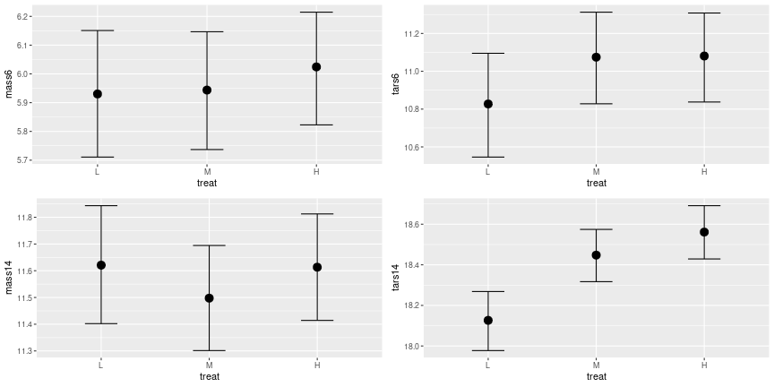

# Back to the questions

## 1. How much are the four measures of size affected by incubation temperature?

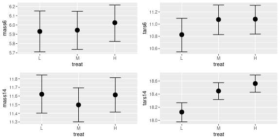

## 2. How does this effect (if any) compare to other sources of variation?

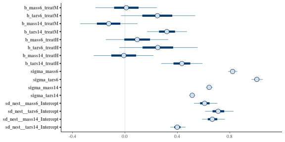

## 3. Is there an effect of “nest”

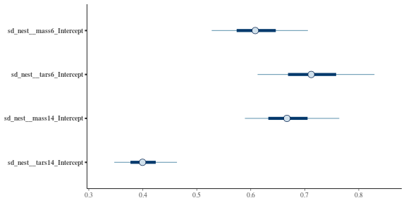

## …and is it correlated between the four measures?

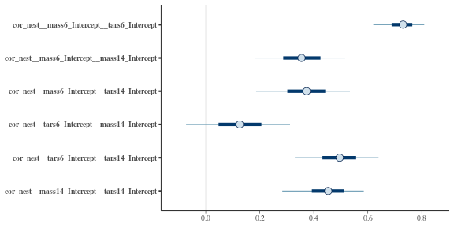

## 4. How correlated are the four measurements, after accounting for other variables?

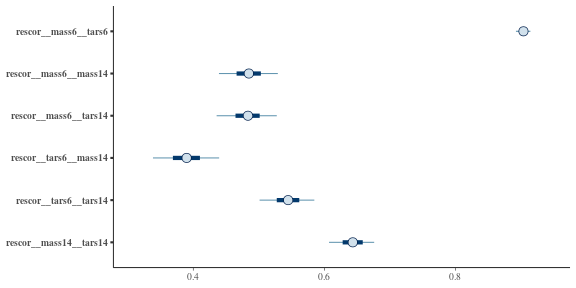

# Model comparison

## Did adding `nest` improve the model?

Comparing the models comes down to asking: (how much) does knowing measurements of others in the same nest help predict a nestling’s measurements?

this is a job for

**crossvalidation**

## Fancy-pants crossvalidation

```r
bm1_kfold <- kfold(bm1, K=5, save_fits=TRUE)
```

```
## Fitting model 1 out of 5
```

```
## Fitting model 2 out of 5
```

```
## Fitting model 3 out of 5
```

```
## Fitting model 4 out of 5
```

```
## Fitting model 5 out of 5
```

```r
bm2_kfold <- kfold(bm2, K=5, folds='stratified', group='nest', save_fits=TRUE)
```

```
## Fitting model 1 out of 5
```

```
## Fitting model 2 out of 5
```

```
## Fitting model 3 out of 5
```

```
## Fitting model 4 out of 5
```

```
## Fitting model 5 out of 5
```

## Extract out-of-sample predictions

```r
## DOESN'T WORK?!?!
kpred1 <- kfold_predict(bm1_kfold)
kpred2 <- kfold_predict(bm2_kfold)
```

```r
get_rmse <- function (kf) {
    varnames <- c("mass6", "tars6", "mass14", "tars14")
    rmse <- expand.grid(variable=varnames,
                        fold=1:5)
    rmse$rmse <- NA
    for (k in 1:5) {
        oos_indices <- kf$fits[[5+k]]
        stopifnot(all(oos_indices <= nrow(kf$data)))
        obs <- kf$data[oos_indices,]
        oos_data <- data.frame(lapply(kf$data, "[", oos_indices))
        exp <- predict(kf$fits[[k]], newdata=oos_data)[,"Estimate",]
        for (vn in varnames) {
            which_row <- which(rmse$variable == vn & rmse$fold == k)
            stopifnot(length(which_row) == 1)
            rmse$rmse[which_row] <- sqrt(mean((obs[,vn] - exp[,vn])^2))
        }
    }
    return(rmse)
}
rmse <- rbind(cbind(get_rmse(bm1_kfold), model=1),
              cbind(get_rmse(bm2_kfold), model=2))
```

## Compute root-mean-squared-error

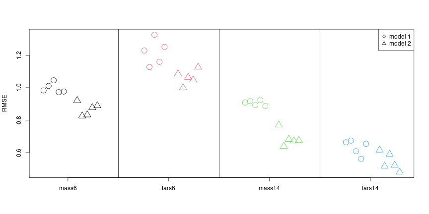